# Predictive Pipeline for Robust Classification

```r
# Missing values per column
miss_df <- df %>%
  summarise(across(everything(), ~ sum(is.na(.)))) %>%
  pivot_longer(everything(), names_to = "feature", values_to = "n_missing") %>%
  arrange(desc(n_missing))
miss_df %>% head(20)
## # A tibble: 20 × 2
##    feature                               n_missing
##    <chr>                                     <int>
##  1 feat_local_CTDD_prop3.G1.residue25            6
##  2 feat_local_CTDD_prop7.G1.residue75            6
##  3 feat_local_CTDT_prop7.Tr1221                  5
##  4 feat_local_QSO_Schneider.Xr.A                 5
##  5 feat_local_ScalesGap_scl3.lag1                5
##  6 feat_local_ScalesGap_scl5.2.lag1              5
##  7 feat_local_CTDC_polarizability.Group3         4
##  8 feat_local_CTDD_prop1.G2.residue75            4
##  9 feat_local_CTDD_prop3.G2.residue25            4
## 10 feat_local_CTDD_prop4.G3.residue50            4
## 11 feat_local_CTDD_prop5.G3.residue75            4
## 12 feat_local_CTDD_prop7.G3.residue75            4
## 13 feat_local_CTDD_prop7.G3.residue100           4
## 14 feat_local_QSO_Grantham.Xr.S                  4
## 15 feat_local_ScalesGap_scl1.3.lag1              4
## 16 feat_local_Entropy                            3
## 17 feat_local_MolWeight                          3
## 18 feat_local_AAtypes_Polar                      3
## 19 feat_local_AAC_G                              3
## 20 feat_local_CTDC_hydrophobicity.Group1         3

# Class distribution (imbalance check)
df %>%
  count(!!sym(TARGET)) %>%
  mutate(pct = n / sum(n)) %>%
  arrange(desc(n))
## # A tibble: 2 × 3
##   Class     n   pct
##   <fct> <int> <dbl>
## 1 -1     4382 0.592
## 2 1      3021 0.408

# Group sizes (leakage risk indicator)
if ("Info_group" %in% names(df)) {
  df %>%
    count(Info_group) %>%
    summarise(
      n_groups = n(),
      min_group_size = min(n),
      median_group_size = median(n),
      max_group_size = max(n)
    )
}
## # A tibble: 1 × 4
##   n_groups min_group_size median_group_size max_group_size
##      <int>          <int>             <int>          <int>
## 1      545              1                 2            598
```

To understand scaling differences and tail behaviour (which can destabilise linear models), I summarise numeric columns and inspect the most variable ones.

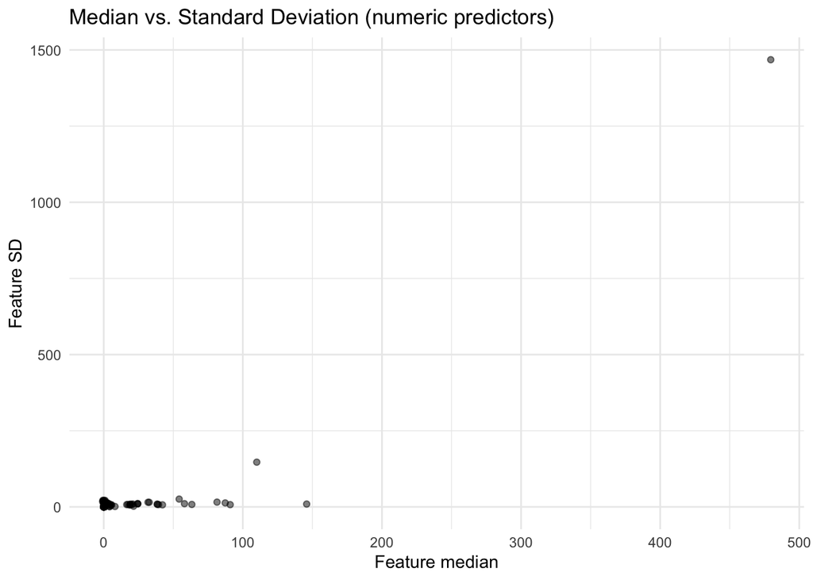

```r
# Keep only numeric features
numeric_df <- df %>% select(where(is.numeric))

# Compute median & SD for each numeric column
summary_stats <- numeric_df %>%
  summarise(across(everything(), list(median = median, sd = sd), .names = "{.col}_{.fn}")) %>%
  pivot_longer(everything(),
               names_to = c("feature", "stat"),
               names_pattern = "(.*)_(.*)",
               values_to = "value")

# Scatterplot of median vs SD (scale differences)
summary_stats %>%
  pivot_wider(names_from = stat, values_from = value) %>%
  ggplot(aes(x = median, y = sd)) +
  geom_point(alpha = 0.5) +
  theme_minimal() +
  labs(title = "Median vs. Standard Deviation (numeric predictors)",
       x = "Feature median",
       y = "Feature SD")
## Warning: Removed 263 rows containing missing values or values outside the scale range
## (`geom_point()`).
```

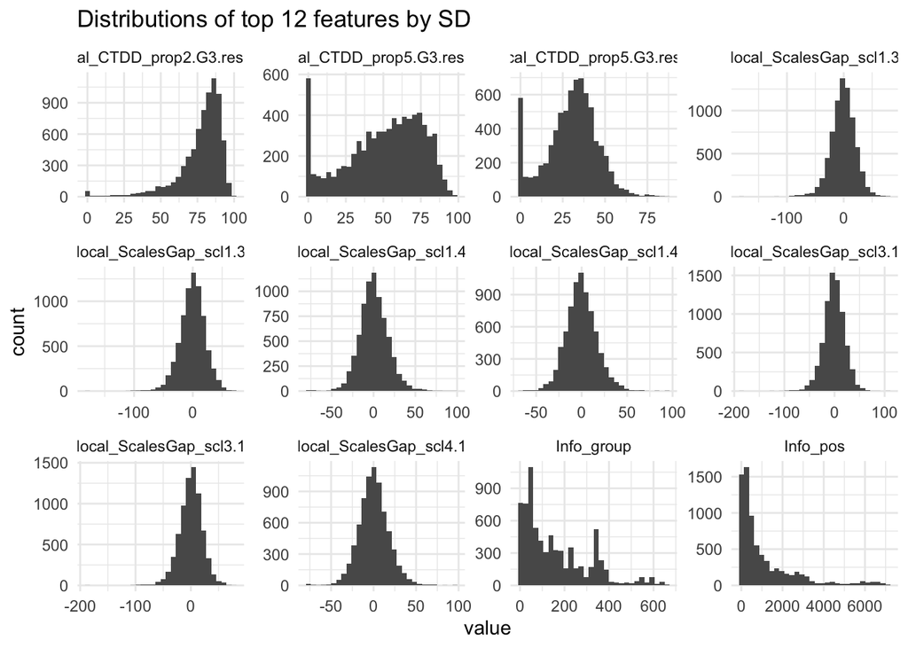

```r
# 12 features with largest SD
top_sd_features <- summary_stats %>%
  filter(stat == "sd") %>%
  arrange(desc(value)) %>%
  slice_head(n = 12) %>%
  pull(feature)

# Histograms of these features (skew/outliers)
df %>%
  select(all_of(top_sd_features)) %>%
  pivot_longer(everything(), names_to = "feature", values_to = "value") %>%
  ggplot(aes(value)) +
  geom_histogram(bins = 30) +
  facet_wrap(~ feature, scales = "free") +
  theme_minimal() +
  ggtitle("Distributions of top 12 features by SD")
```

EDA takeaway (what this implies for the pipeline):

- `Info_group` suggests a dependency structure → use **group-aware split/CV**.
- Missing values are present → include **imputation** inside the workflow.
- Numeric predictors show scale differences and skew → use **Yeo–Johnson + scaling**.
- Predictors are numerous and correlated → prefer **regularisation and/or PCA**.
- Class is mildly imbalanced → handle imbalance inside training only.